# Cluster 筆記ξ( ✿＞◡❛)

以下為R中運行的各分群方法，內容含：

1.需要輸入的資料類型

2.所需設定的參數

3.比較在不同資料集下的表現

```r
#所需套件
#install.packages("dbscan")
library(dbscan)
#install.packages("factoextra")
library(factoextra)
#install.packages("fpc")
library(fpc)
library(magrittr)
library(gridExtra)
library(anocva)
#install.packages('cluster')
library(cluster)
#install.packages("proxy")
library(proxy)
#install.packages("SNFtool")
library(SNFtool)
library(apcluster)
library(kernlab)
```

```r
#測試資料1
data(multishapes)
head(multishapes)
```

|  | x | y | shape |
| --- | --- | --- | --- |
| 1 | -0.8037393 | -0.8530526 | 1 |
| 2 | 0.8528507 | 0.3676184 | 1 |
| 3 | 0.9271795 | -0.2749024 | 1 |
| 4 | -0.7526261 | -0.5115652 | 1 |
| 5 | 0.7068462 | 0.8106792 | 1 |
| 6 | 1.0346985 | 0.3946550 | 1 |

```r
df = multishapes[, 1:2]
#測試資料2
df2 = matrix(c( rnorm(1000,mean =-10 , sd = 1), rnorm(1000,mean =10 , sd = 10),
                rnorm(1000,mean =-10 , sd = 1), rnorm(1000,mean =10 , sd = 10)),ncol =2)
```

# Kmeans

### ※輸入資料

原矩陣

### ※設定參數

k : 決定要分幾群

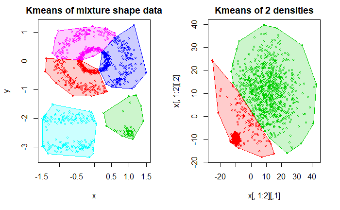

```r
set.seed(1281)
par(mfrow = c(1,2))
km.res = kmeans(df, 5, nstart = 25)
hullplot(df,  km.res$cluster, main = "Kmeans of mixture shape data")
km.res2 = kmeans(df2, 2, nstart = 25)
hullplot(df2,  km.res2$cluster, main = "Kmeans of 2 densities")
```

Kmeans在分群上，普遍被認為是最簡單直覺的分群方法，所需要決定的參數也只有需要分為幾群， 然而其在面臨非線性的資料時表現變差，且使用歐式距離的方法也會受到*維度詛咒*(以下的方法仍也有這個問題)， 然而，面對多密度線性資料問題時(第一群正確率:100% 第二群正確率:88.5%)，此方法受到的影響比較小。

# Hieratical clustering

### ※輸入資料

原矩陣的距離矩陣

### ※設定參數

k : 決定要分幾群

or

h :決定要在哪裡分割

```r
clusters <- hclust(dist(df))
clusters2 <- hclust(dist(df2))
par(mfrow = c(1,2))
plot(clusters,labels = F)
plot(clusters2,labels = F,main = "Dataset: 2 densities")
```

[figure not shown]

```r
par(mfrow = c(2,2))
```

```r
#以線性的角度而言或許此資料分三群較佳
clusterCut <- cutree(clusters, 5)
hullplot(df,  clusterCut, main = "Hieratical clustering clusters = 5")
clusterCut <- cutree(clusters, 3)
hullplot(df,  clusterCut, main = "Hieratical clustering clusters = 3")
```

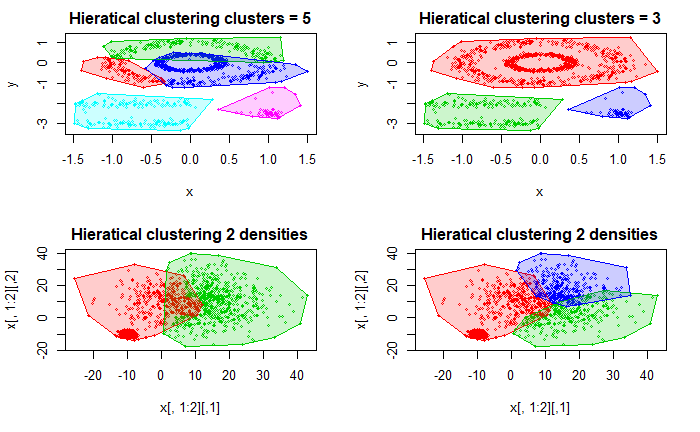

```r
clusterCut2 <- cutree(clusters2, 2)
hullplot(df2,  clusterCut2, main = "Hieratical clustering 2 densities")
clusterCut <- cutree(clusters2, 3)
hullplot(df2,  clusterCut, main = "Hieratical clustering 2 densities")
```

階層式分群法的分群結果與Kmeans相近，透過樹狀圖可以比較清楚的來決定分群的群數，而由於輸入的矩陣是距離矩陣， 或許可以嘗試歐式距離以外的距離(如DTW)。而其結果遇到非線性的資料表現比較差，在面對資料多密度時，以樹狀圖決定的分群也會失真 (第一群正確率:100% 第二群正確率:13.8%)。

# DBSCAN

### ※輸入資料

原矩陣

### ※設定參數

eps : 定義多近的距離才是近 Minpts : 在距離eps內至少要出現幾個點才判斷「主要點」

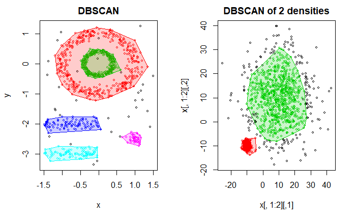

```r
par(mfrow = c(1,2))
db = fpc::dbscan(df, eps = 0.15, MinPts = 5)
hullplot(df, db, main = "DBSCAN")
db2 = fpc::dbscan(df2, eps = 3, MinPts = 15)
hullplot(df2, db2, main = "DBSCAN of 2 densities")
```

DBSCAN方法，相較Kmeans，為基於*密度*的分群方法，在非線性的資料中表現較好， 雖然不須決定所分群數為較廣為人知的優點之一，實際上在運用時，若對資料沒有一定了解， 其所決定的參數，並沒有比較容易，仍需要try-error。

在面臨多密度資料時，雖然可以透過定義鄰近點個數來避免分群過多的問題，但會因此犧牲太多點，不過從另外一個角度看， 此方法也能順便找出*極端值*(第一群正確率:100% 第二群正確率:83.1% 未分類:16.3%)。

# OPTICS

### ※輸入資料

原矩陣

### ※設定參數

eps_cl : 定義多近的距離才是近

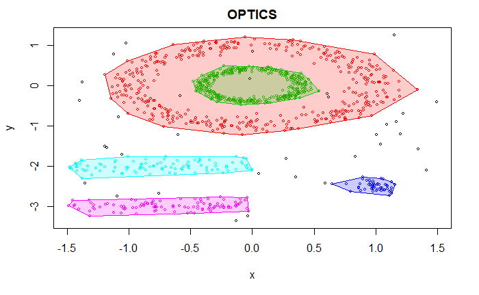

```r
dopt = dbscan::optics(df)
#note : eps_cl can't be too low or too high#
doptres = extractDBSCAN(dopt,eps_cl = .15)
hullplot(df, doptres, main = "OPTICS")
par(mfrow = c(1,3))
```

```r
dopt2 = dbscan::optics(df2)
#note : eps_cl can't be too low or too high#
doptres2 = extractDBSCAN(dopt2,eps_cl = 2.5)
hullplot(df2, doptres2, main = "OPTICS of 2 densities, eps = 2.5")
dopt2 = dbscan::optics(df2)
#note : eps_cl can't be too low or too high#
doptres2 = extractDBSCAN(dopt2,eps_cl = 3.1)
hullplot(df2, doptres2, main = "OPTICS of 2 densities, eps = 3.1")
```

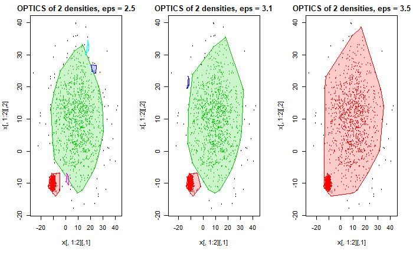

```r
dopt3 = dbscan::optics(df2)
#note : eps_cl can't be too low or too high#
doptres3 = extractDBSCAN(dopt2,eps_cl = 3.5)
hullplot(df2, doptres3, main = "OPTICS of 2 densities, eps = 3.5")
```

OPTICS 基於 DBSCAN，在參數選擇上少決定了*Minpts*，其eps設定要與DBSCAN差不多， 簡化了決定最小鄰近點的過程。但在多密度的資料中，由於完全不能決定其最少鄰近點，可能會造成分群群數不是過多就是過少的情形 (第一群正確率:100% 第二群正確率:94.7% 未分類或其他類:4.7% 類別多出1類)。

# Spectral Cluster

### ※輸入資料

距離矩陣或可被做成距離矩陣的資料型

### ※設定參數

centers : 層數

```r
par(mfrow = c(1,3))
set.seed(1218)
spec.by.seed = specc(as.matrix(df),centers=5)
hullplot(df,  spec.by.seed, main = "Spectral cluster, seed =  1218")
set.seed(1281)
spec.by.seed = specc(as.matrix(df),centers=5)
hullplot(df,  spec.by.seed, main = "Spectral cluster, seed = 1281")
```

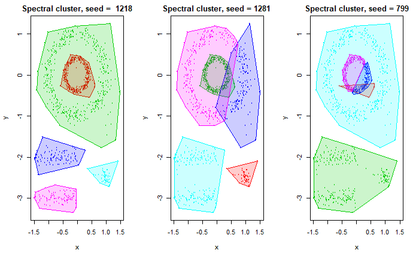

```r
set.seed(799)
spec.by.seed = specc(as.matrix(df),centers=5)
hullplot(df,  spec.by.seed, main = "Spectral cluster, seed = 799")
```

```r
spec2 = specc(as.matrix(df2),centers=2)
```

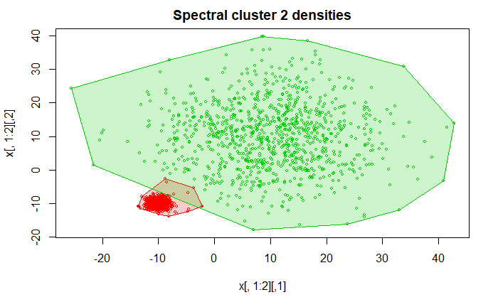

```r
hullplot(df2,  spec2, main = "Spectral cluster 2 densities")
```

使用spectral分群對非線性資料與多密度資料(第一群正確率:100%、第二群正確率:98.9%)皆有不錯的結果，且所有點都會被歸類 。

然而，此方法的運行時間是以上的分群法中最久的，且其分群結果不太穩定，根據起始點的不同，最後結果差距甚大。 另外，此方法的輸入資料不需要是連續函數，可以推廣到類別型，或時間序列型。

*▲題外話:Spectral cluster 在R上的許多套件都不太好用，其中kernlab中的specc是最好的，但好慢。*